# FOMC Word Watcher

christoffer.nordenlow@outlook.com

## Text mining FOMC Minutes 2020-11-05

*Below analysis aims to give colour on FOMC Minutes in terms of the overall sentiment as well as which topics and words that are hot and cold.*

*To be able to to compare Minutes by different length with each other, everything below is set in relation to total the number of words or paragraph in their respective Minutes. Please see more information at description and methodology.*

*Contents include:*

General sentiment

Economic and financial market conditions

Policy toolbox and topics

In deeper breakdown of selected topics

### General sentiment

#### Net sentiment

*Net sentiment is calculated by extracting all positive and negative words, and then taking the difference between these divided by the total number of words.*

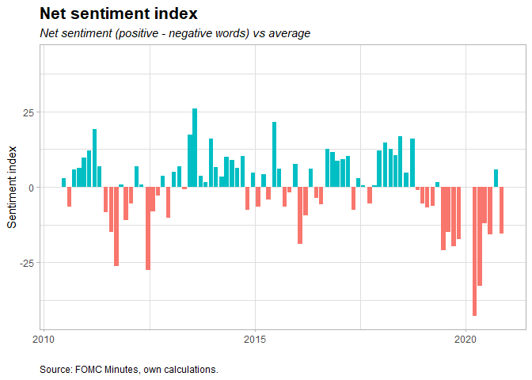

#### Intensifier-index

*Intensifier-index shows the magnitude of the net sentiment by setting positive and negative words in combination with intensifier words (e.g. extremely, significant, sharply etc).*

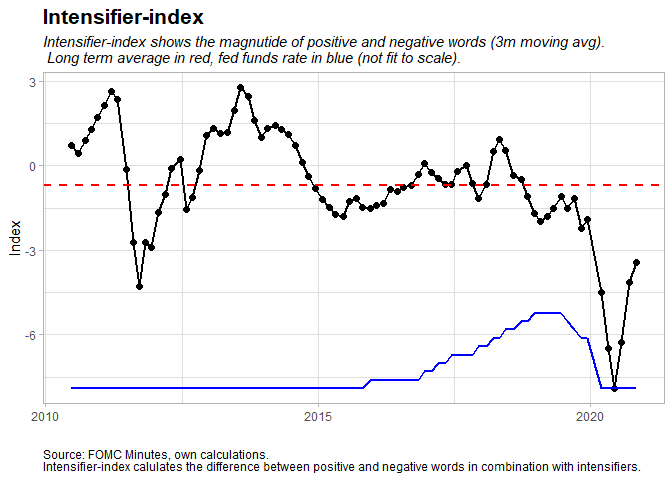

#### Selected sentiment words

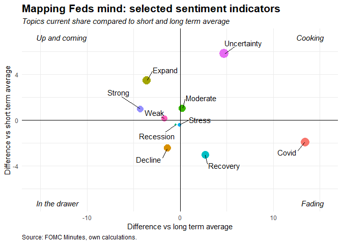

#### Strong-Weak-Moderate - Index

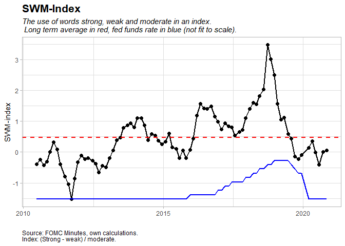

### Economic and financial market conditions

#### Economic topics

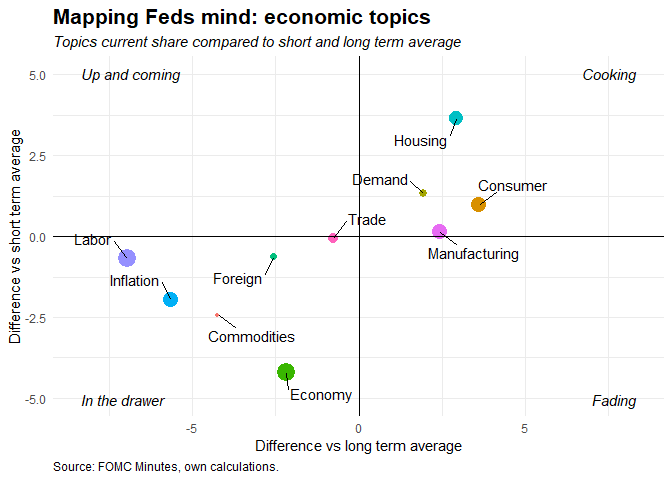

#### Sentiment analysis of economic topics

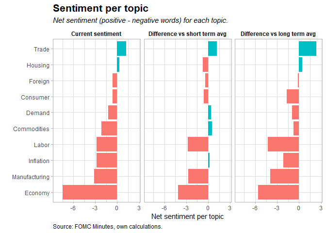

#### Financial markets

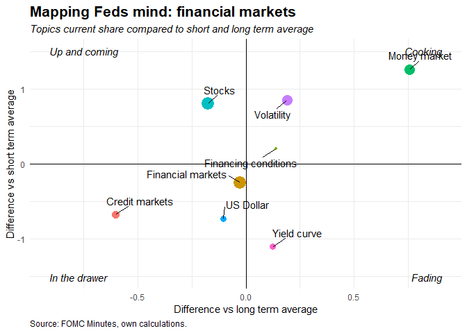

#### Sentiment analysis of financial markets

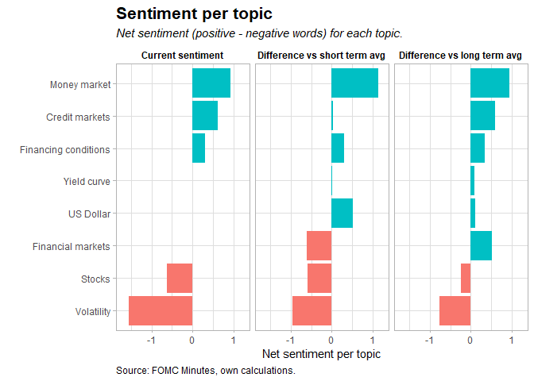

### Policy toolbox and topics

#### Policy toolbox

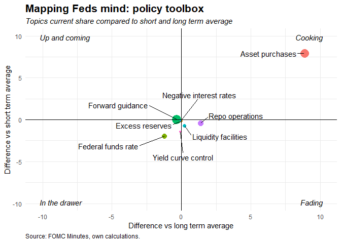

#### Policy key words

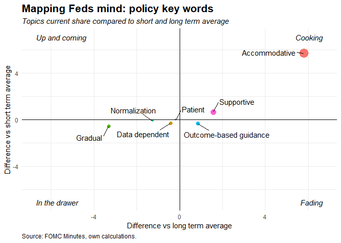

#### Key-words-O-Meters

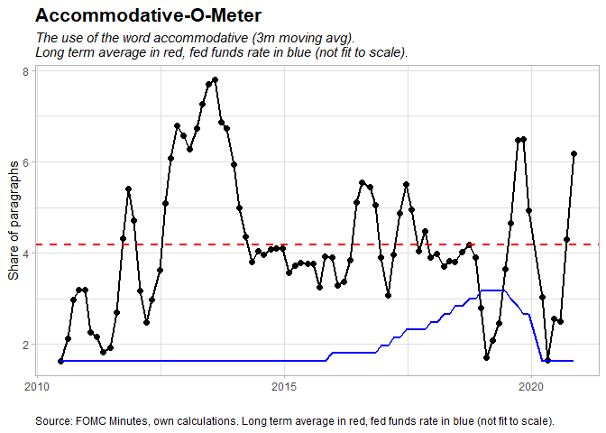

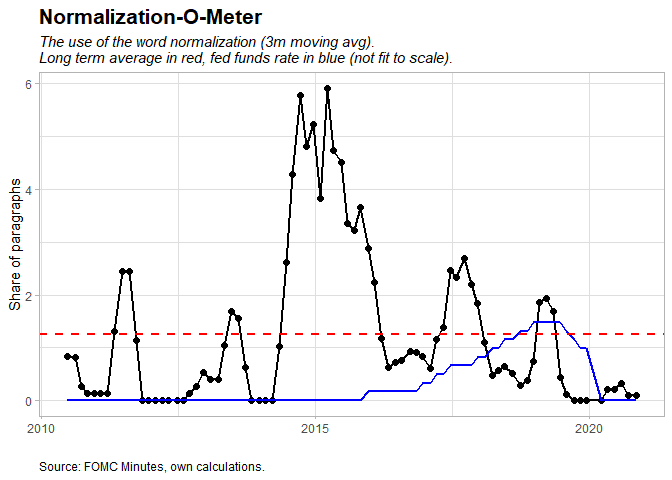

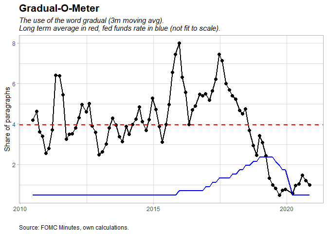

#### Policy action

*The graph below show the difference between sentences containing words like consensus, majority, all and those of words like a few, one or two. Above red dotted line suggest there are a more consensus view among participants then when below the dotted red line.*

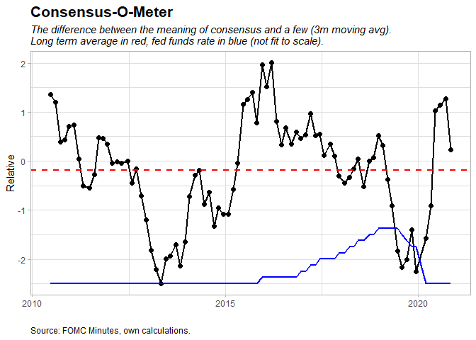

### In deeper breakdown

#### Inflation

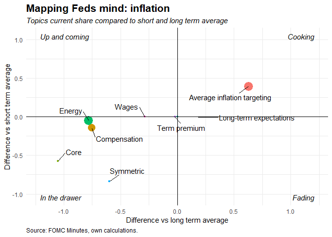

#### Labor market

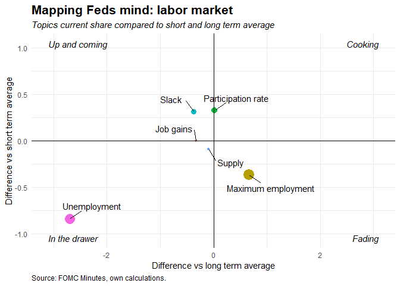

#### Asset purchases

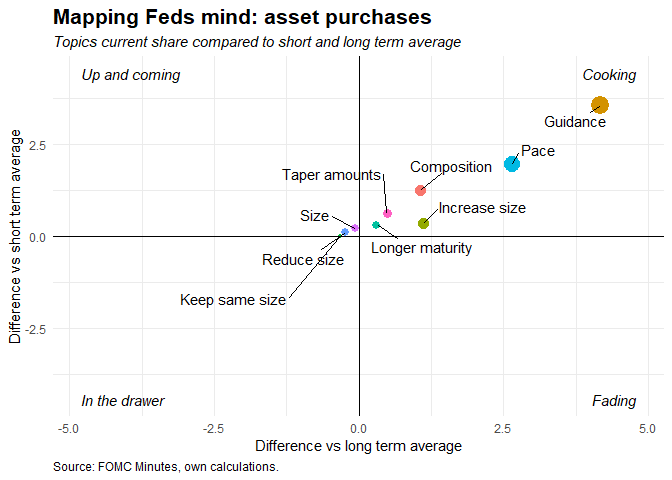

### Description and Methodology

Please see more information on *[github](https://github.com/cnordenlow/fomc-word-watcher)*.

**Methodology**  
The approach of this project are as follows.

- Words and topics are divided into bag of words of its meaning (e.g. the word “strong” may consists of [“strong”, “stronger”, “strongest”, “strengthen”]).
- Text are divided into sentences that cleaned for special characters, extra spaces and then tokenized and lemmatized, then converted back to a sentence.
- All sentences are iterated where it checks for the different bag of words and then counted, (e.g. if the word “stronger” is found in a sentence, the count adds one regardless of how many time strong is in the sentence.) For most topics, a second loop followed which counts negative and positive words in the same sentence to get the net sentiment for each topic.

*The purpose with the bag of words format is to being able to get part of sentences grouped for their meaning. E.g. for being able to find more colour on asset purchases (tapering amounts, reducing the program, increasing the program), it´s not sufficient to map a sentence with the word of “reduce” and “asset purchase” in the same, but it´s needed to get more of the context for being (more) sure of the meaning.*

The methodology used in this project include use of Python for web parsing and text mining, producing .csv files. R is then used for some additional calculations and to render a Markdown report with vizualisations. Some notes below of the different parts.

**Web parsing**  
All web parsing is done using BeautifulSoup package. The code first parse all .htm pages with the url of “Minutes” in it for the year of interest. Then, a second loop parse all the (chosen) Minutes for the text mining. In both parsing steps, there are a time delay of a couple of seconds.

**Text mining**  
With the help of the great package of NLTK, the Minutes are cleaned and converted to a more gentle format. A pretty long(:/) loop are then iterated that runs a set of inner loops for getting the information for each Minutes.

**Vizualisation**  
R is used for some further calculations and Markdown for creating a report.